# Prediction Assignment Write Up

Nica Stefan

30 octombrie 2017

# 1. Overview

The current document is the final report of Peer Assesment Project from Coursera’s course Practical Machine Learning, specialization Data Science. It’s build in RStudio, using its knitr functions and published in html format. The goal of the project is to predict how 6 participants performed some exercise as described below. This is the “classe” variable in the training set. The algorithm built here will be applied to 20 test cases available in test data and the predictions are submitted in appropiate format to the Course Project Prediction Quiz for grading.

# 2. Summary

Using latest technology we are able to collect a large amount of data about personal activity. These type of devices gives us quantified self movement data, for us to have a clear picture about our health and to find different behaviours in our bodies. One of the most common things is getting the number of exercises and not the quality of execution. We will use data from accelerometers of 6 participants. They performed barbell lifts correctly and incorrently in 5 different ways. More information : http://groupware.les.inf.puc-rio.br/har

# 3. Data Preprocessing

# 3.1 Data

Train set : https://d396qusza40orc.cloudfront.net/predmachlearn/pml-training.csv

Test set : https://d396qusza40orc.cloudfront.net/predmachlearn/pml-testing.csv

# 3.2 Loading packages

```r
library(knitr)
library(caret)
```

```r
library(rpart)
library(rpart.plot)
library(randomForest)
library(corrplot)
library(ggplot2)
library(caret)
library(ggcorrplot)
library(GGally)
set.seed(1000)
```

# 3.3 Data Preprocessing

```r
train <- read.csv(TrainFile)
dim(train)
```

```
## [1] 19622   160
```

```r
test <- read.csv(TestFile)
dim(test)
```

```
## [1]  20 160
```

```r
# creating data partition
inTrain <- createDataPartition(train$classe, p = 0.7, list = FALSE)
TrainSet <- train[inTrain,]
TestSet <- train[-inTrain,]

dim(TrainSet)
```

```
## [1] 13737   160
```

```r
dim(TestSet)
```

```
## [1] 5885  160
```

```r
#Both datasets have equal number of variables. Nor, for a better prediction we will exclude NA's, the Near Zone Variance and the Identification variables

#Removing variables with Nearly Zero Variance

nearzerovariance <- nearZeroVar(TrainSet)
TrainSet <- TrainSet[,-nearzerovariance]
TestSet <- TestSet[,-nearzerovariance]
dim(TrainSet)
```

```
## [1] 13737   106
```

```r
dim(TestSet)
```

```
## [1] 5885  106
```

```r
#Removing variables which are almost NA

RmvNA <- sapply(TrainSet, function(x) mean(is.na(x))) > 0.95
TrainSet <- TrainSet[,RmvNA==FALSE]
TestSet <- TestSet[,RmvNA==FALSE]
dim(TrainSet)
```

```
## [1] 13737    59
```

```r
dim(TestSet)
```

```
## [1] 5885   59
```

```r
#Removing Identification columns 1:5

TrainSet <- TrainSet[,-(1:5)]
TestSet <- TestSet[,-(1:5)]
dim(TestSet)
```

```
## [1] 5885   54
```

```r
dim(TrainSet)
```

```
## [1] 13737    54
```

# 4. Prediction Model Building

We will apply the most popular three solutions to model the regressions: Random Forest, Decision Tree and Generalized Boosted Model. A Confusion Matrix is plotted at the end of each model and the one one with the best accuracy will be used for the quiz predictions.

# 4.1 Random Forest

```r
#model fitting
ctrlRF <- trainControl(method = "cv", number =3, verboseIter = FALSE)
modfitRF <- train(classe ~., data = TrainSet, method = "rf", trControl = ctrlRF)
modfitRF$finalModel
```

```
##
## Call:
##  randomForest(x = x, y = y, mtry = param$mtry)
##                Type of random forest: classification
##                      Number of trees: 500
## No. of variables tried at each split: 27
##
##         OOB estimate of  error rate: 0.25%
## Confusion matrix:
##      A    B    C    D    E  class.error
## A 3904    1    0    0    1 0.0005120328
## B    8 2648    2    0    0 0.0037622272
## C    0    6 2389    1    0 0.0029215359
## D    0    0   10 2242    0 0.0044404973
## E    0    0    0    6 2519 0.0023762376
```

```r
# predicting on test dataset
predictRF <- predict(modfitRF, newdata = TestSet)
CMRF <- confusionMatrix(predictRF,TestSet$classe)
CMRF
```

```
## Confusion Matrix and Statistics
##
##           Reference
## Prediction    A    B    C    D    E
##          A 1674    5    0    0    0
##          B    0 1133    2    0    0
##          C    0    1 1024    5    0
##          D    0    0    0  959    4
##          E    0    0    0    0 1078
##
## Overall Statistics
##
##                Accuracy : 0.9971
##                  95% CI : (0.9954, 0.9983)
##     No Information Rate : 0.2845
##     P-Value [Acc > NIR] : < 2.2e-16
##
##                   Kappa : 0.9963
##  Mcnemar's Test P-Value : NA
##
## Statistics by Class:
##
##                      Class: A Class: B Class: C Class: D Class: E
## Sensitivity            1.0000   0.9947   0.9981   0.9948   0.9963
## Specificity            0.9988   0.9996   0.9988   0.9992   1.0000
## Pos Pred Value         0.9970   0.9982   0.9942   0.9958   1.0000
## Neg Pred Value         1.0000   0.9987   0.9996   0.9990   0.9992
## Prevalence             0.2845   0.1935   0.1743   0.1638   0.1839
## Detection Rate         0.2845   0.1925   0.1740   0.1630   0.1832
## Detection Prevalence   0.2853   0.1929   0.1750   0.1636   0.1832
## Balanced Accuracy      0.9994   0.9972   0.9984   0.9970   0.9982
```

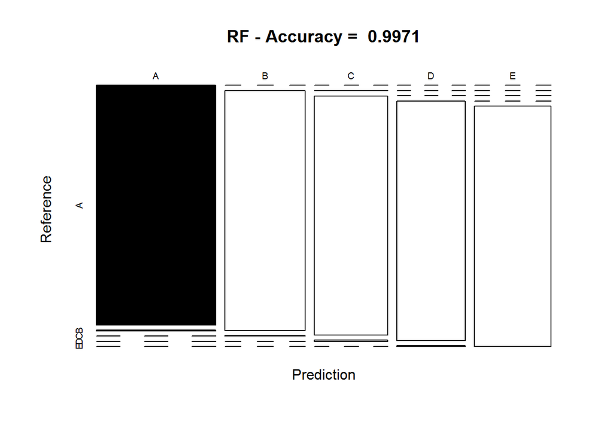

```r
#plot matrix results
plot(CMRF$table, col = CMRF$byClass, main = paste("RF - Accuracy = ", round(CMRF$overall['Accuracy'],4)))
```

# 4.2 Decision Tree

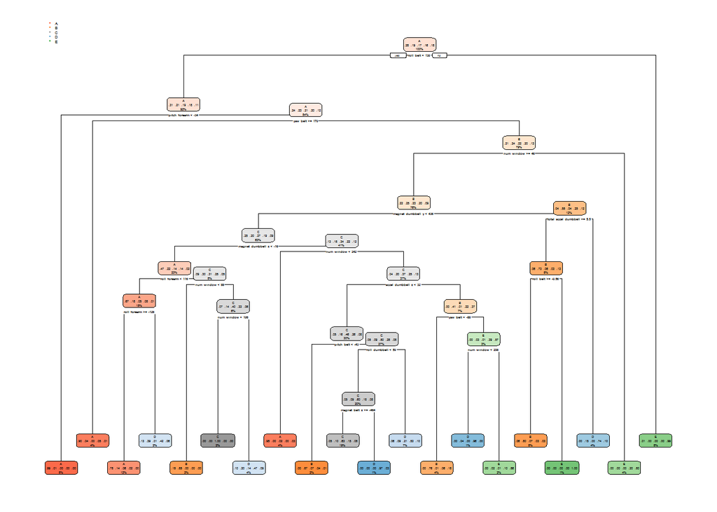

```r
#model fitting
modfitDT <- rpart(classe ~ ., data=TrainSet, method="class")
rpart.plot(modfitDT)
```

```r
#predicting on test dataset
predictDT <- predict(modfitDT, newdata=TestSet, type="class")
CMDT <- confusionMatrix(predictDT, TestSet$classe)
CMDT
```

```
## Confusion Matrix and Statistics
##
##           Reference
## Prediction    A    B    C    D    E
##          A 1499  117   55   26   16
##          B   38  709   51   24   50
##          C   59  106  797  177   95
##          D   75  200  122  675  100
##          E    3    7    1   62  821
##
## Overall Statistics
##
##                Accuracy : 0.7648
##                  95% CI : (0.7538, 0.7756)
##     No Information Rate : 0.2845
##     P-Value [Acc > NIR] : < 2.2e-16
##
##                   Kappa : 0.7028
##  Mcnemar's Test P-Value : < 2.2e-16
##
## Statistics by Class:
##
##                      Class: A Class: B Class: C Class: D Class: E
## Sensitivity            0.8955   0.6225   0.7768   0.7002   0.7588
## Specificity            0.9492   0.9657   0.9101   0.8990   0.9848
## Pos Pred Value         0.8751   0.8131   0.6459   0.5759   0.9183
## Neg Pred Value         0.9581   0.9142   0.9508   0.9387   0.9477
## Prevalence             0.2845   0.1935   0.1743   0.1638   0.1839
## Detection Rate         0.2547   0.1205   0.1354   0.1147   0.1395
## Detection Prevalence   0.2911   0.1482   0.2097   0.1992   0.1519
## Balanced Accuracy      0.9223   0.7941   0.8434   0.7996   0.8718
```

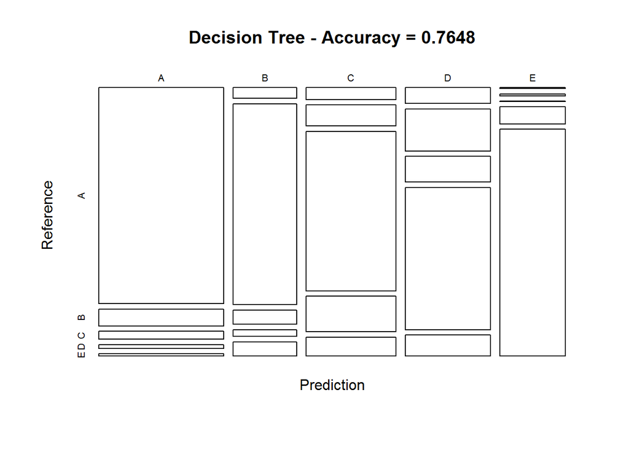

```r
#plot matrix results
plot(CMDT$table, col = CMDT$byClass,
     main = paste("Decision Tree - Accuracy =",
                  round(CMDT$overall['Accuracy'], 4)))
```

# 4.3 Generalized Boosted Model

```r
#model fitting
ctrlGBM <- trainControl(method = "repeatedcv", number = 5, repeats = 1)
modFitGBM  <- train(classe ~ ., data=TrainSet, method = "gbm",
                    trControl = ctrlGBM, verbose = FALSE)
modFitGBM$finalModel
```

```
## A gradient boosted model with multinomial loss function.
## 150 iterations were performed.
## There were 53 predictors of which 41 had non-zero influence.
```

```r
# predicting on test dataset
predictGBM <- predict(modFitGBM, newdata=TestSet)
CMGBM <- confusionMatrix(predictGBM, TestSet$classe)
CMGBM
```

```
## Confusion Matrix and Statistics
##
##           Reference
## Prediction    A    B    C    D    E
##          A 1670   16    0    0    0
##          B    4 1120   11    6    2
##          C    0    3 1014   21    7
##          D    0    0    0  936   13
##          E    0    0    1    1 1060
##
## Overall Statistics
##
##                Accuracy : 0.9856
##                  95% CI : (0.9822, 0.9884)
##     No Information Rate : 0.2845
##     P-Value [Acc > NIR] : < 2.2e-16
##
##                   Kappa : 0.9817
##  Mcnemar's Test P-Value : NA
##
## Statistics by Class:
##
##                      Class: A Class: B Class: C Class: D Class: E
## Sensitivity            0.9976   0.9833   0.9883   0.9710   0.9797
## Specificity            0.9962   0.9952   0.9936   0.9974   0.9996
## Pos Pred Value         0.9905   0.9799   0.9703   0.9863   0.9981
## Neg Pred Value         0.9990   0.9960   0.9975   0.9943   0.9954
## Prevalence             0.2845   0.1935   0.1743   0.1638   0.1839
## Detection Rate         0.2838   0.1903   0.1723   0.1590   0.1801
## Detection Prevalence   0.2865   0.1942   0.1776   0.1613   0.1805
## Balanced Accuracy      0.9969   0.9892   0.9910   0.9842   0.9896
```

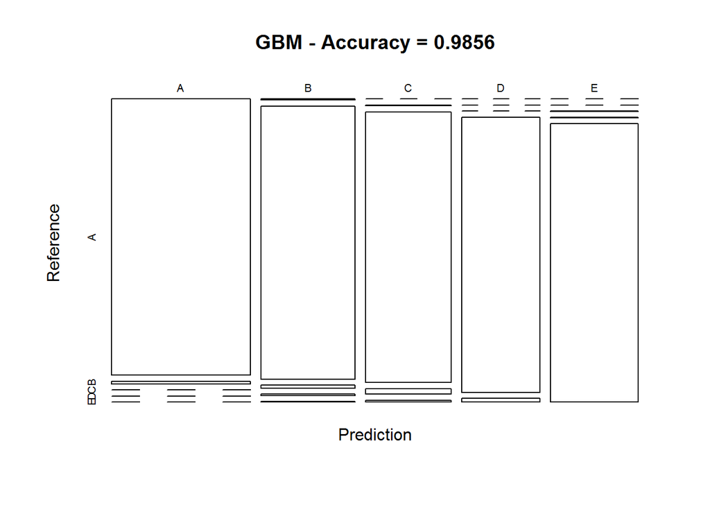

```r
# plot matrix results
plot(CMGBM$table, col = CMGBM$byClass,
     main = paste("GBM - Accuracy =", round(CMGBM$overall['Accuracy'], 4)))
```

# 5. Aplying the selected Model to the Test Data

The accuracy of the three models used is: Rf : 0.9971 DT : 0.7648 GBM : 0.9856

Due to this results I will use the Random Forest model to predict the 20 results (testing dataset)

```r
predictTEST <- predict(modfitRF, newdata=test)
predictTEST
```

```
##  [1] B A B A A E D B A A B C B A E E A B B B
## Levels: A B C D E
```